# Dimension Reduction for Real Estate

The main goal of this study was to reduce the dimensions of collected data regarding real estate. The database includes variables describing houses features and all of them are continuous. Moreover, it was decided that the PCA would be the most suitable method for the study purposes. The aim of this method is to obtain principle components which would describe some part of the data variances.

## Exploratory data analysis

The first step in this study was to analyze the data. The database is constructed with 38 variables and their names are uploaded below.

```r
data = read.csv("realestate.csv")
print(as.data.frame.list(colnames(data)))
```

```
##   X.Id. X.MSSubClass. X.LotFrontage. X.LotArea. X.OverallQual. X.OverallCond.
## 1    Id    MSSubClass    LotFrontage    LotArea    OverallQual    OverallCond
##   X.YearBuilt. X.YearRemodAdd. X.MasVnrArea. X.BsmtFinSF1. X.BsmtFinSF2.
## 1    YearBuilt    YearRemodAdd    MasVnrArea    BsmtFinSF1    BsmtFinSF2
##   X.BsmtUnfSF. X.TotalBsmtSF. X.X1stFlrSF. X.X2ndFlrSF. X.LowQualFinSF.
## 1    BsmtUnfSF    TotalBsmtSF    X1stFlrSF    X2ndFlrSF    LowQualFinSF
##   X.GrLivArea. X.BsmtFullBath. X.BsmtHalfBath. X.FullBath. X.HalfBath.
## 1    GrLivArea    BsmtFullBath    BsmtHalfBath    FullBath    HalfBath
##   X.BedroomAbvGr. X.KitchenAbvGr. X.TotRmsAbvGrd. X.Fireplaces. X.GarageYrBlt.
## 1    BedroomAbvGr    KitchenAbvGr    TotRmsAbvGrd    Fireplaces    GarageYrBlt
##   X.GarageCars. X.GarageArea. X.WoodDeckSF. X.OpenPorchSF. X.EnclosedPorch.
## 1    GarageCars    GarageArea    WoodDeckSF    OpenPorchSF    EnclosedPorch
##   X.X3SsnPorch. X.ScreenPorch. X.PoolArea. X.MiscVal. X.MoSold. X.YrSold.
## 1    X3SsnPorch    ScreenPorch    PoolArea    MiscVal    MoSold    YrSold
##   X.SalePrice.
## 1    SalePrice
```

Each of the variable is numeric and is describing different house features. So, the first thing that was checked was the number of missing values. It appeared that there is 348 of them out of 1460. Thus, it was decided to omit those values because it was assumed that the methodology would work better without them.

```r
sum(is.na(data))
```

```
## [1] 348
```

```r
nrow(data)
```

```
## [1] 1460
```

```r
data = na.omit(data)
```

### Data description

It is visible on the table below that collected dataset includes many kind of variables. Using it in different types of analysis might be in some way inefficient. Mainly, due to the fact that in these big databases the same information might be provided with multiple variables and this means that using them is not optimal from computational and simplicity reasons. Thus, this is the purpose to reduce the dimension of the data.

```r
describe(data)
```

```
##               vars    n      mean       sd median   trimmed      mad   min
## Id               1 1121    726.84   420.77    725    726.12   541.15     1
## MSSubClass       2 1121     56.15    41.77     50     48.44    44.48    20
## LotFrontage      3 1121     70.67    24.27     70     69.56    14.83    21
## LotArea          4 1121  10122.96  8129.30   9416   9491.53  2805.08  1300
## OverallQual      5 1121      6.21     1.38      6      6.17     1.48     2
## OverallCond      6 1121      5.56     1.07      5      5.45     0.00     2
## YearBuilt        7 1121   1972.26    30.97   1974   1975.35    38.55  1880
## YearRemodAdd     8 1121   1985.68    21.03   1995   1987.37    17.79  1950
## MasVnrArea       9 1121    108.49   189.50      0     66.19     0.00     0
## BsmtFinSF1      10 1121    438.40   468.39    374    375.51   554.49     0
## BsmtFinSF2      11 1121     44.59   157.83      0      0.93     0.00     0
## BsmtUnfSF       12 1121    594.13   450.26    506    547.52   429.95     0
## TotalBsmtSF     13 1121   1077.12   445.66   1008   1052.59   355.82     0
## X1stFlrSF       14 1121   1173.58   386.17   1097   1142.95   351.38   438
## X2ndFlrSF       15 1121    353.26   438.56      0    291.95     0.00     0
## LowQualFinSF    16 1121      4.57    41.60      0      0.00     0.00     0
## GrLivArea       17 1121   1531.41   523.72   1479   1481.43   462.57   438
## BsmtFullBath    18 1121      0.41     0.51      0      0.38     0.00     0
## BsmtHalfBath    19 1121      0.06     0.23      0      0.00     0.00     0
## FullBath        20 1121      1.58     0.55      2      1.58     0.00     0
## HalfBath        21 1121      0.38     0.50      0      0.34     0.00     0
## BedroomAbvGr    22 1121      2.86     0.77      3      2.85     0.00     0
## KitchenAbvGr    23 1121      1.04     0.21      1      1.00     0.00     1
## TotRmsAbvGrd    24 1121      6.58     1.59      6      6.45     1.48     3
## Fireplaces      25 1121      0.60     0.63      1      0.53     1.48     0
## GarageYrBlt     26 1121   1978.40    25.82   1981   1981.14    32.62  1900
## GarageCars      27 1121      1.88     0.65      2      1.84     0.00     1
## GarageArea      28 1121    502.96   191.24    484    488.75   177.91   160
## WoodDeckSF      29 1121     92.61   121.87      0     71.49     0.00     0
## OpenPorchSF     30 1121     46.13    64.39     27     33.35    40.03     0
## EnclosedPorch   31 1121     21.84    61.28      0      3.74     0.00     0
## X3SsnPorch      32 1121      3.35    29.77      0      0.00     0.00     0
## ScreenPorch     33 1121     16.10    57.80      0      0.00     0.00     0
## PoolArea        34 1121      2.93    40.22      0      0.00     0.00     0
## MiscVal         35 1121     23.43   165.76      0      0.00     0.00     0
## MoSold          36 1121      6.34     2.69      6      6.29     2.97     1
## YrSold          37 1121   2007.80     1.34   2008   2007.74     1.48  2006
## SalePrice       38 1121 185506.15 82999.16 164900 173950.75 58414.44 35311
##                  max  range  skew kurtosis      se
```

[output cut: 23 more lines]

```
## TotRmsAbvGrd      12      9  0.72     0.71    0.05
## Fireplaces         3      3  0.64    -0.15    0.02
## GarageYrBlt     2010    110 -0.64    -0.56    0.77
## GarageCars         4      3  0.21    -0.41    0.02
## GarageArea      1418   1258  0.73     0.81    5.71
## WoodDeckSF       857    857  1.55     3.35    3.64
## OpenPorchSF      547    547  2.40     8.99    1.92
## EnclosedPorch    552    552  3.16    11.32    1.83
## X3SsnPorch       508    508 10.83   135.76    0.89
## ScreenPorch      480    480  4.01    17.42    1.73
## PoolArea         648    648 13.75   189.15    1.20
## MiscVal         2500   2500  9.67   109.32    4.95
## MoSold            12     11  0.17    -0.42    0.08
## YrSold          2010      4  0.11    -1.21    0.04
## SalePrice     755000 719689  1.93     6.38 2478.97
```

### Correlation

The next step was to verify the correlation between variables. It is a crucial part because it gives some preview about relationships between the house features. Based on the correlation analysis is possible to check whether methods of reducing dimensions will be suitable for this dataset.

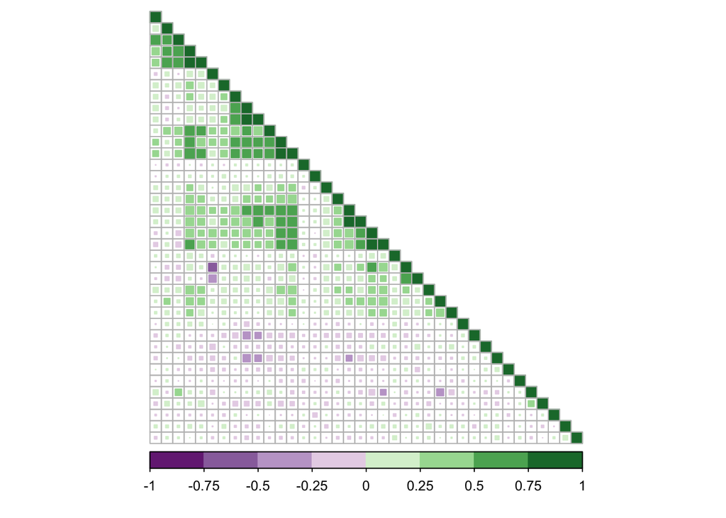

```r
data_corr = cor(data)
corrplot(data_corr,method=c("square"), type="lower", order="hclust",tl.pos = "n",
         col=brewer.pal(n=8, name="PRGn"))
```

Based on the correlation matrix it might be visible that there are numerous variables which are strongly correlated with each other. We can observe some huge blocks with strong filling. This observation leads to conclusion that some methods of dimension reduction could be used on this database.

### Data standardization

The last step in the data manipulation was the standardization. The reason for that was the different scales of the variables.

```r
data_z = as.data.frame(lapply(data[2:38],scale))
```

## Dimension Reduction

After initial data analysis it is time for reducing the dimension of the data. However, at the beginning it should be decided which method should be used. By taking the purpose of the study into account it was determined that PCA method should be picked up. First of all this method is a really good tool to handle the relationships and variances between all the variables by creating principal components. Moreover, it provides a really good insights into data and helps with understanding it. Although, PCA has many advantages it also has some drawbacks. Basically, it does not perform well with the data containing outliers and characterized with non-linear relationships.

### PCA

As it was said in the previous section the PCA method has been chosen to reduce the dimensions. Below there are presented the results of this method and based on them number of principal components was established.

```r
data_PCA = prcomp(data, center = TRUE, scale. = TRUE)
summary(data_PCA)
```

```
## Importance of components:
##                           PC1     PC2     PC3     PC4     PC5     PC6     PC7
## Standard deviation     2.8671 1.77742 1.64505 1.42931 1.23913 1.12178 1.10593
## Proportion of Variance 0.2163 0.08314 0.07122 0.05376 0.04041 0.03312 0.03219
## Cumulative Proportion  0.2163 0.29946 0.37067 0.42444 0.46484 0.49796 0.53014
##                            PC8     PC9    PC10    PC11    PC12    PC13    PC14
## Standard deviation     1.06819 1.06555 1.05167 1.03896 1.01790 1.01307 0.96156
## Proportion of Variance 0.03003 0.02988 0.02911 0.02841 0.02727 0.02701 0.02433
## Cumulative Proportion  0.56017 0.59005 0.61916 0.64756 0.67483 0.70184 0.72617
##                           PC15    PC16    PC17    PC18   PC19    PC20    PC21
## Standard deviation     0.95680 0.94446 0.91815 0.88946 0.8739 0.86407 0.82790
## Proportion of Variance 0.02409 0.02347 0.02218 0.02082 0.0201 0.01965 0.01804
## Cumulative Proportion  0.75026 0.77373 0.79592 0.81674 0.8368 0.85648 0.87452
##                           PC22    PC23    PC24   PC25    PC26   PC27    PC28
## Standard deviation     0.80337 0.77629 0.72749 0.6865 0.62910 0.6197 0.56748
## Proportion of Variance 0.01698 0.01586 0.01393 0.0124 0.01041 0.0101 0.00847
## Cumulative Proportion  0.89150 0.90736 0.92129 0.9337 0.94411 0.9542 0.96269
##                           PC29    PC30    PC31    PC32    PC33   PC34    PC35
## Standard deviation     0.52108 0.50338 0.45351 0.41880 0.38884 0.3750 0.34386
## Proportion of Variance 0.00715 0.00667 0.00541 0.00462 0.00398 0.0037 0.00311
## Cumulative Proportion  0.96983 0.97650 0.98191 0.98653 0.99051 0.9942 0.99732
##                           PC36      PC37      PC38
## Standard deviation     0.31927 1.517e-15 5.914e-16
## Proportion of Variance 0.00268 0.000e+00 0.000e+00
## Cumulative Proportion  1.00000 1.000e+00 1.000e+00
```

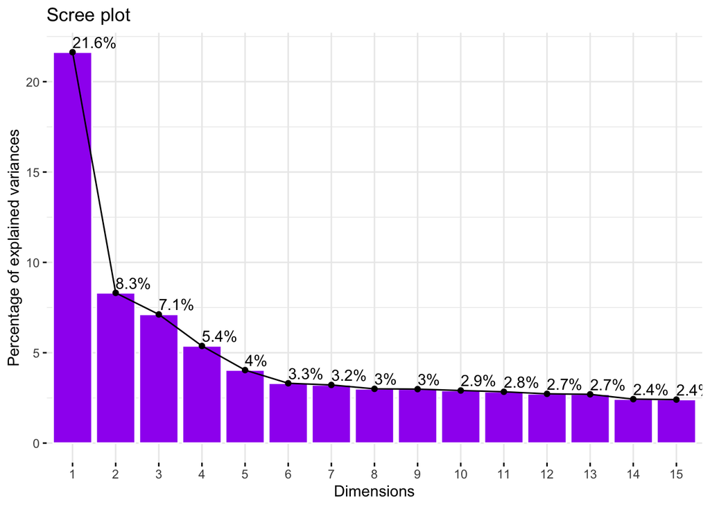

```r
fviz_screeplot(data_PCA, addlabels = TRUE, ncp = 15, barfill = "purple", barcolor = "white")
```

As it is visible on the table and plot it is difficult to choose optimal number of the principle components. The principle components chosen by the elbow method might not provide enough information because there will be less then 50% of variance explained. Thus, it was decided that the optimal number of components should be chosen arbitrary based on the variance explained willing to be obtained. In this study it was determined that it should be 90%, so finally 23 components has been chosen. However, to verify the decision, in the table below, the eigen values have been calculated. These results pointed that optimal number of components should be 13, because the eigenvalue of the rest of the components was lower than one. Thus, finally it was decided to go with 13 components.

```r
ev_table = get_eigenvalue(data_PCA)
ev_table[1:15,]
```

```
##        eigenvalue variance.percent cumulative.variance.percent
## Dim.1   8.2201753        21.632040                    21.63204
## Dim.2   3.1592156         8.313725                    29.94577
## Dim.3   2.7062056         7.121594                    37.06736
## Dim.4   2.0429367         5.376149                    42.44351
## Dim.5   1.5354528         4.040665                    46.48417
## Dim.6   1.2583992         3.311577                    49.79575
## Dim.7   1.2230798         3.218631                    53.01438
## Dim.8   1.1410371         3.002729                    56.01711
## Dim.9   1.1354037         2.987905                    59.00502
## Dim.10  1.1060052         2.910540                    61.91556
## Dim.11  1.0794395         2.840630                    64.75619
## Dim.12  1.0361298         2.726657                    67.48284
## Dim.13  1.0263207         2.700844                    70.18369
## Dim.14  0.9246034         2.433167                    72.61685
## Dim.15  0.9154609         2.409108                    75.02596
```

### Visualisation

In the next section some visualizations were presented. The purpose of that was to give some insights about the results. In this section the focus was only on the first two components because simply they provide the most information.

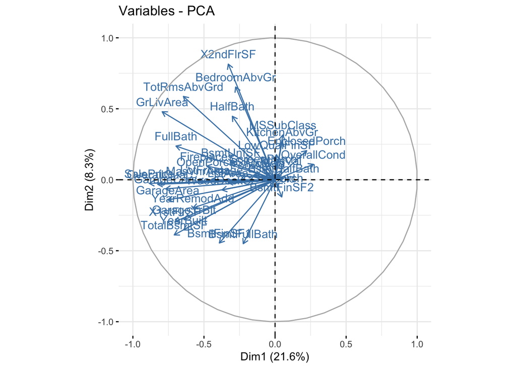

```r
fviz_pca_var(data_PCA, col.var="steelblue")
```

Based on this graphs it was possible to obtain some information about relationships between variables. What is quite unusual here is the fact that almost all these variables are placed on the left side of vertical axis. It means that all these variables are positively correlated.

The next graph represents individual observation in two dimensions with colored quality of representation.

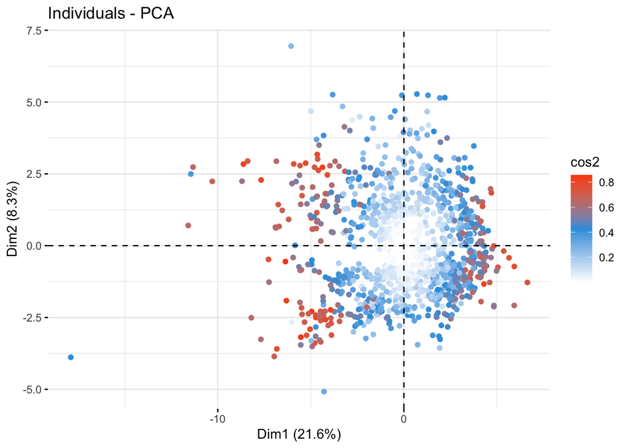

```r
fviz_pca_ind(data_PCA, col.ind="cos2", geom="point", gradient.cols=c("white", "#2E9FDF", "#FC4E07" ))
```

The plots below present the contributions of individual variables to two first principal components.

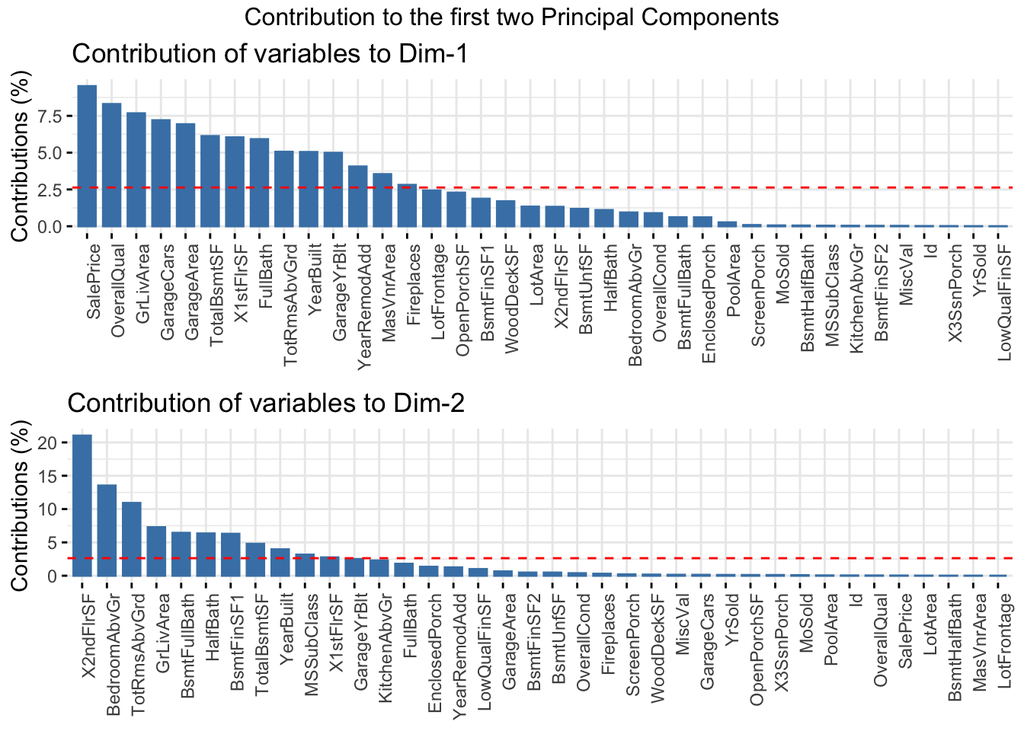

```r
var = get_pca_var(data_PCA)
a = fviz_contrib(data_PCA, "var", axes=1, xtickslab.rt=90)
b = fviz_contrib(data_PCA, "var", axes=2, xtickslab.rt=90)
grid.arrange(a,b,top='Contribution to the first two Principal Components')
```

## Clustering

The additional step in this analysis was preparing some clustering. Thus, at the beginning it was necessary to calculate Silhuette statistics for couple of clusters. It will provide information about optimal number of clusters. As a default method the k-means has been chosen.

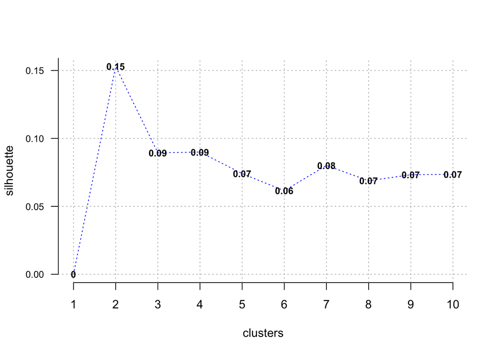

```r
kmeans_opt = Optimal_Clusters_KMeans(data_z, max_clusters=10, plot_clusters=TRUE, criterion="silhouette")
```

Based on the plot it was possible to determine optimal number of clusters. It is visible that the highest score was assigned to the two clusters and this was the number used in further analysis. Now, lets plot our clusters.

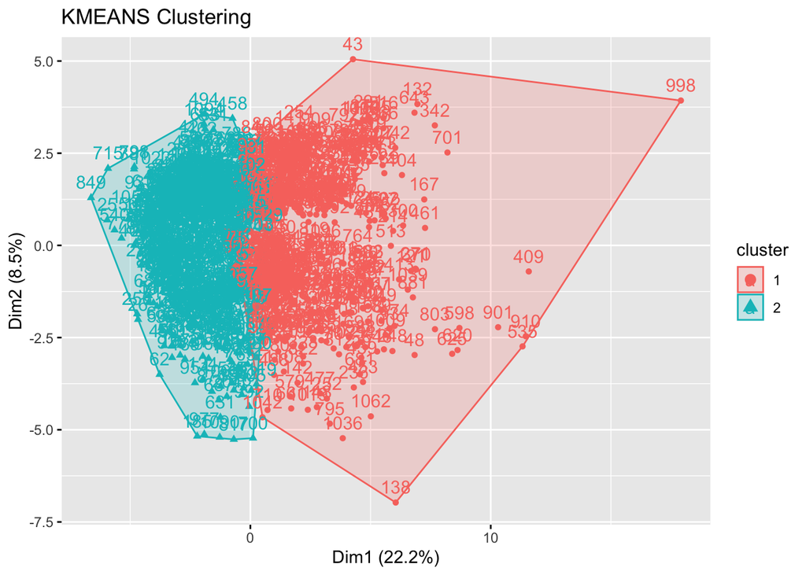

```r
km3 = eclust(data_z, k=2)
```

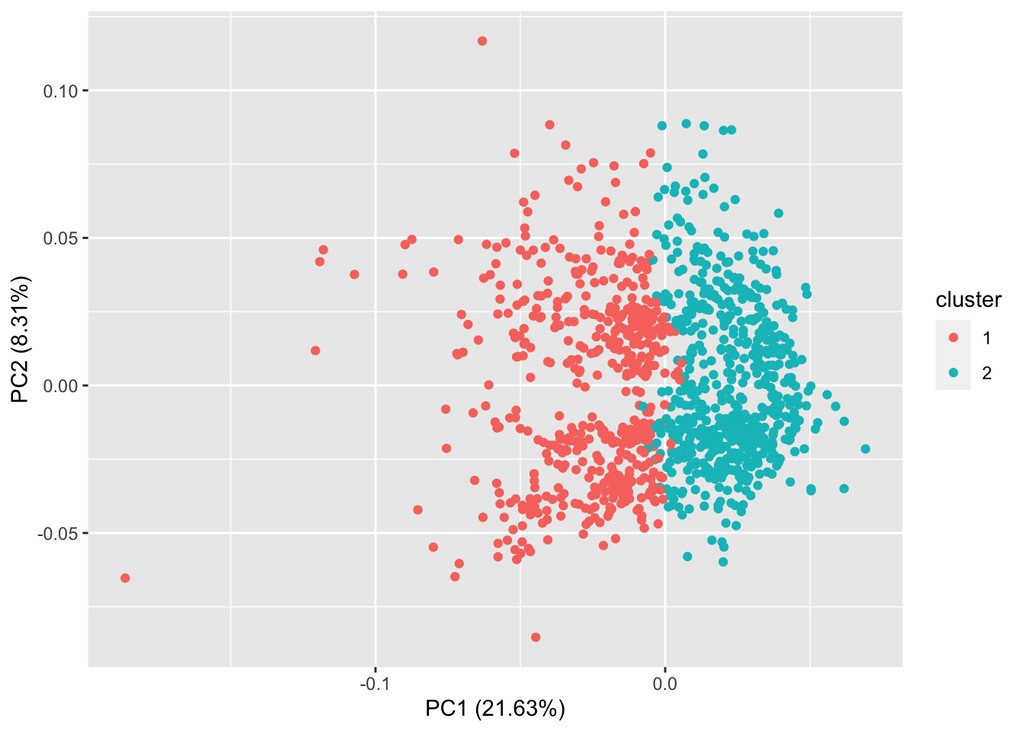

```r
autoplot(data_PCA, data = km3, colour = "cluster")
```

## Summary

To conclude, the aim of this study was to reduce the dimensions of the real estate database. The reason for that was to get more information about the data and obtain variables which will be more pleasant to work with. The initial number of variables was 38 and the PCA method allowed us to reduce it down to 13 principle components an they were explaining more than 70% of the variance. At the end some basic clustering on the results was presented. Based on the silhuette statistics two culsters were established and plotted. It is also visible that clustering results on the whole data set are similar to PCA results.s

## References

http://www.sthda.com/english/articles/31-principal-component-methods-in-r-practical-guide/112-pca-principal-component-analysis-essentials/

https://www.datacamp.com/community/tutorials/pca-analysis-r

https://cran.r-project.org/web/packages/ggfortify/vignettes/plot_pca.html